# Project 5

STATS 220 Semester One 2023

(Alex) Jiacheng Wei

2023-05-22

# Introduction

### Data Focus

I chose 2 countries which according to Al-Jazeera [https://www.aljazeera.com/news/2023/2/16/mapping-where-every-country-stands-on-the-russia-ukraine-war] were in full support of the illegal Russian invasion of Ukraine.

The aim is to see if there are any music choice differences which may arise from the differences of the audience of New Zealand against Russia and Belarus.

New Zealand condemns Russia’s invasion of Ukraine and perhaps there is some relationship between the stances of the governments on the international stage and the civilian music choice.

SQL

To find the songs that appear on both of two different playlists using a SQL query, you can use a combination of SQL JOIN and WHERE clauses.

I would determine how the playlists and songs are related. Usually there woudl be a foreign key in the songs table which refrences the playlist ID in the playlists table.

Use the JOIN clause to combine two tables then use the WHERE clause to specify the condition that selects songs which appear in both playlists.

# Data Creations

### Static Visualisation

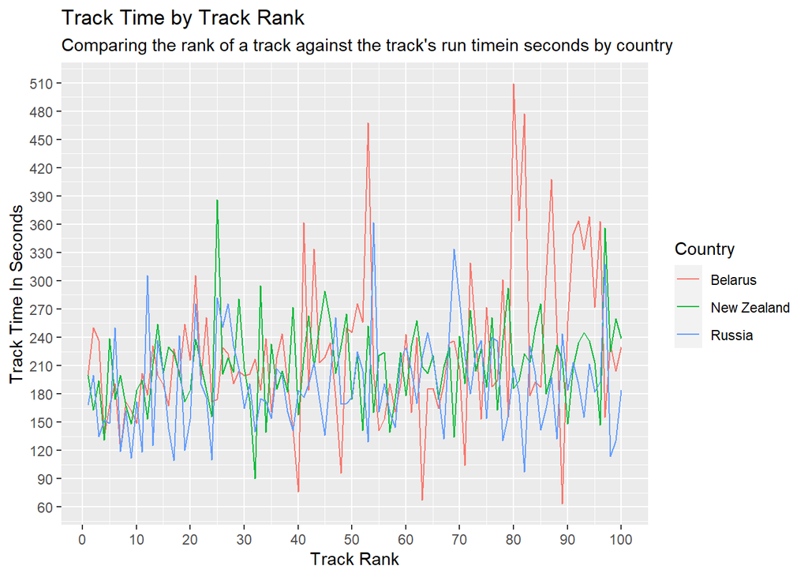

This shows tells us that the Belarusian Top 100 includes a number of songs longer than average. Perhaps Belarusians have a taste for long songs?

[output not shown]

[output cut: 136 more lines]

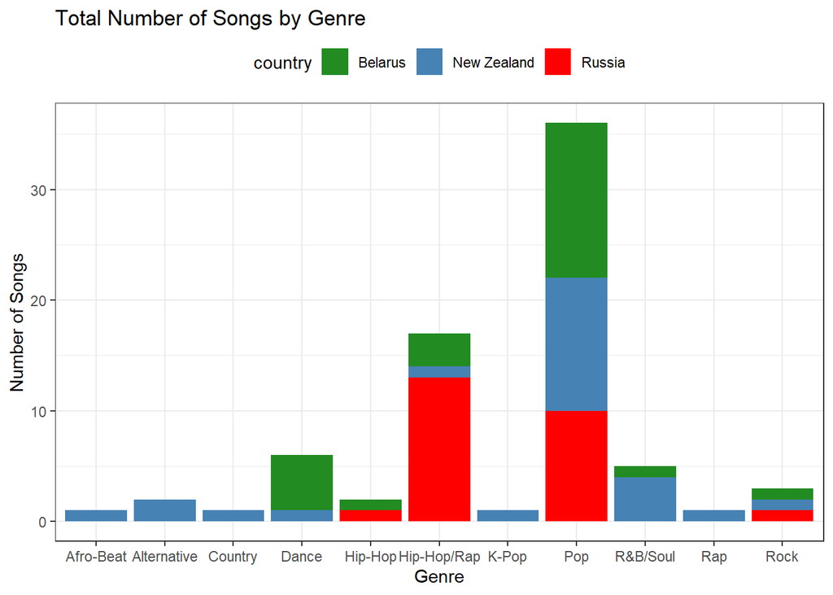

This stacked bar graph shows how many songs are in each genre, with each country colour coded.

I have utilised knowledge of ggplot for data visualisation (colour, stacked bar graph) and data manipulation techniques (arrange, bind_rows, slice) and data gathering techniques (fromJSON, itunesAPI search by track_id).

I have used all of these techniques together in conjunction to create a stacked bar graph that is both informative, easy to read, and utilises primaryGenreName, a variable we were taught how to access in Project 3.

# Final Reflection

**One important** idea I have learned from Module 5: Creating data from digital sources is web scraping.

I have utilised rvest and jsonlite to scrape information from the web from both the playlist from itunes and to use that data to further utilise the API to get primary genres.

This module has taught me the limitations of webscraping, specifically how we may need to use Sys.sleep() to slow down our web-scraping as web services have updated their security to prevent bad actors from overloading requests.

It has also taught me the unknown dangers of time. In album_web, due to the time it takes to run one of album_web’s “function” to get album information, I need to wait for a while in order for web scraping to work.

**Overall**, I have learnt the complexities of data visualisation, manipulation, and gathering and the amount of work it goes into processing such data. I have learnt the value of data quality and the intricicies of how useful data is collected and how it differs from un-useful data. I have learnt the flexability of R and it’s many libraries to not only produce a visualisation of data, but to create web page to present them in context.

**I am curious** of the complexities of data communication and how we can more effectively communicate data not only in data visualisation but beyond in written form or something else. I am also interested in perhaps representing data in even more complex forms.

# Appendix

```r
library(tidyverse)
library(rvest)


# 2 countries that are against condemning Russia for the illegal invasion of Ukraine:
# Russia and Belarus according to Al-Jazeera
# [https://www.aljazeera.com/news/2023/2/16/mapping-where-every-country-stands-on-the-russia-ukraine-war]


url_ru <- "https://music.apple.com/us/playlist/top-100-russia/pl.728bd30a9247487c80a483f4168a9dcd"
url_br <- "https://music.apple.com/us/playlist/top-100-belarus/pl.50c1747c37404a9aa07acc39316f6873"
url_nz <- "https://music.apple.com/us/playlist/top-100-new-zealand/pl.d8742df90f43402ba5e708eefd6d949a"

page_ru <- read_html(url_ru)
page_br <- read_html(url_br)
page_nz <- read_html(url_nz)

page_list <- list(page_ru, page_br, page_nz)

process_url <- function(page) {
  # artificial delay
  Sys.sleep(2)

  track_id <- page %>%
    html_elements(".songs-list") %>%
    html_elements("a") %>%
    html_attr("href") %>%
    .[str_detect(., "/song/")] %>%
    str_remove_all("https://(.*)/song/(.*)/")

  track_rank <- page %>%
    html_elements(".songs-list-row__rank") %>%
    html_text2()

  album_id <- page %>%
    html_elements(".songs-list__col.songs-list__col--tertiary") %>%
    html_elements(".songs-list__song-link-wrapper") %>%
    html_elements("a") %>%
    html_attr("href") %>%
    str_remove_all("https://(.*)/album/(.*)/")

  track_time <- page %>%
    html_elements(".songs-list-row__length") %>%
    html_text2()

  track_name <- page %>%
    html_elements(".songs-list-row__song-name") %>%
    html_text2()

  artist_name <- page %>%
    html_elements(".songs-list-row__by-line") %>%
    html_text2()

  heading <- page %>%
    html_elements(".headings__title") %>%
    html_text2()
  country <- str_sub(heading, start = 10)

  return(list(track_id = track_id, track_rank = track_rank, album_id = album_id, track_time = track_time, track_name = track_name, artist_name = artist_name, country = country))
}

# Run the above code to get song_data dataframe of all top 100 songs of the 2 countries which supoort war the invasion and 1 country which does not.
song_data <- map_df(page_list, process_url)
# save the data in the .rds format
saveRDS(song_data, "song_data.rds")
```

```r
library(tidyverse)
library(rvest)

#Read song_data from .rds file
song_data <- readRDS("song_data.rds")

# get unique value of album id's from the dataframe song_data
# as a vector on it's own.
album_ids <- song_data$album_id %>% unique()

counter <- 0
# Function that processes album ids
process_album_id <- function(album_id) {

  counter <<- counter + 1
  print(counter)
  if (counter == 100 || counter == 200){
    # artificial delay
    Sys.sleep(2)
  }
  url <- paste0("https://music.apple.com/album/", album_id)
  session <- session(url)
  page <- read_html(session)

  album_info <- page %>%
    html_elements(".footer-body") %>%
    html_elements(".description") %>%
    html_text() %>%
    str_split("\n") %>%
    unlist()

  album_release_date <- album_info[1]
  album_time <- album_info[2]


  return(list(album_id = album_id, album_release_date = album_release_date, album_time = album_time))
}

album_data <- map_df(album_ids, process_album_id)

playlist_data <- merge(song_data, album_data, by = "album_id")

saveRDS(playlist_data, "playlist_data.rds")
```

```r
library(tidyverse)
library(ggplot2)
library(stringr)
library(lubridate)
library(jsonlite)
library(dplyr)


playlist_data <- readRDS("playlist_data.rds")

playlist_data <- playlist_data %>%
  group_by(track_id) %>%
  mutate(
    track_time_seconds = as.integer(strsplit(track_time, ":")[[1]][1]) * 60 +
      as.integer(strsplit(track_time, ":")[[1]][2])
  ) %>%
  ungroup()


#############################
# RANK TIME by COUNTRY LINE #
#############################
rank_time_country_data <- playlist_data %>%
  select(track_rank,
         track_time_seconds,
         country)
rank_time_country_data$track_rank <- as.numeric(rank_time_country_data$track_rank)

rank_time_sec_country_plot <- ggplot(data = rank_time_country_data, aes(x = track_rank, y = track_time_seconds, color = country, group = country)) +
  geom_line() +
  labs(subtitle = "Comparing the rank of a track against the track's run timein seconds by country", x = "Track Rank", y = "Track Time In Seconds")+
  ggtitle("Track Time by Track Rank") +
  scale_color_discrete(name = "Country") +
  scale_y_continuous(breaks = seq(0, max(rank_time_country_data$track_time_seconds) + 60, by = 30)) +
  scale_x_continuous(breaks = seq(0, max(rank_time_country_data$track_rank), by = 10))
plot(rank_time_sec_country_plot)

ggsave("song_vis.png", rank_time_sec_country_plot, height = 8, width = 16, units = "in")


#######
# SPLIT

country_split <- split(playlist_data, playlist_data$country)

new_zealand_data <- country_split$"New Zealand"
russia_data <- country_split$Russia
belarus_data <- country_split$Belarus

# For New Zealand dataframe
new_zealand_top25 <- new_zealand_data %>%
  arrange(as.integer(track_rank)) %>%
  slice(1:25)

# For Russia dataframe
russia_top25 <- russia_data %>%
  arrange(as.integer(track_rank)) %>%
  slice(1:25)


# For Belarus dataframe
belarus_top25 <- belarus_data %>%
  arrange(as.integer(track_rank)) %>%
  slice(1:25)

# List of country dataframes
country_dataframes <- list(new_zealand_top25, russia_top25, belarus_top25)

# Combine all songs into one dataframe
top25_all_countries <- bind_rows(country_dataframes)

# Loop over each row in the combined dataframe
for (i in 1:nrow(top25_all_countries)) {
  url <- paste0("https://itunes.apple.com/search?term=", top25_all_countries$track_id[i], "&limit=1")
  print(i)
  tryCatch({
    primary_genre <- fromJSON(url)$results$primaryGenreName
    print(primary_genre)
    top25_all_countries$primary_genre[i] <- primary_genre

    # Delay of 2 seconds after every 25 songs
    if (i %% 25 == 0) {
      Sys.sleep(2)
    }
  }, error = function(e) {
    print(paste("Error occurred for index", i, ":", conditionMessage(e)))
    # Set a default value for primary_genre in case of error
    top25_all_countries$primary_genre[i] <- "N/A"
  })
}



##############
# BAR GRAPHS #
##############
# countries <- list(new_zealand_top25, belarus_top25, russia_top25)
# country_colours <- c("steelblue", "forestgreen", "red")
#
# country_count <- 1
# for (country in countries) {
#   colour <- country_colours[country_count]
#   country_count <<- country_count + 1
#
#   genre_plot <- ggplot(country, aes(x = primary_genre)) +
#     geom_bar(fill = colour) +
#     labs(title = paste("Number of Songs by Genre"),
#          subtitle = names(countries)[i],
#          x = "Genre",
#          y = "Number of Songs")
#
#   filename <- paste0(deparse(substitute(country)), "_bar_graph.png")
#   ggsave(filename, plot = genre_plot, height = 8, width = 8, units = "in")
# }


###############
# STACKED BAR #

stacked_country_colours <- c("forestgreen", "steelblue", "red")

# Create the stacked bar graph
stacked_bar <- ggplot(top25_all_countries, aes(x = primary_genre, fill = country)) +
  geom_bar(position = "stack") +
  labs(title = "Total Number of Songs by Genre",
       x = "Genre",
       y = "Number of Songs") +
  scale_fill_manual(values = stacked_country_colours) +
  theme_bw() +
  theme(legend.position = "top")
ggsave("stacked_bar_graph.png", stacked_bar, height = 8, width = 8, units = "in")


########################################################################################
########################################################################################
#########
# GENRE #
#########

## Test
#url <- paste0("https://itunes.apple.com/search?term=", playlist_data$track_id[i], "&limit=1")
#primary_genre <- fromJSON(url)$results$primaryGenreName
#print(primary_genre)


#
# ###############
# # New Zealand #
# ###############
# counter <- 0
# for (i in 1:nrow(playlist_data)) {
#   if (playlist_data$country[i] != "New Zealand") {
#     next  # Skip to the next iteration if country is not "New Zealand"
#   }
#
#   counter <<- counter + 1
#   print(counter)
#   # Artificial delay
#   # Itunes api hates me
#   #if (counter %% 25 == 0){
#   #  Sys.sleep(10)
#   #}
#   url <- paste0("https://itunes.apple.com/search?term=", playlist_data$track_id[i], "&limit=1")
#
#   tryCatch({
#     primary_genre <- fromJSON(url)$results$primaryGenreName
#     print(primary_genre)
#     playlist_data$primary_genre[i] <- primary_genre
#   }, error = function(e) {
#     print(paste("Error occurred for index", i, ":", conditionMessage(e)))
#     # Set a default value for primary_genre in case of error
#     playlist_data$primary_genre[i] <- "N/A"
#   })
# }
#
# ##########
# # RUSSIA #
# ##########
# counter <- 0
# for (i in 1:nrow(playlist_data)) {
#   if (playlist_data$country[i] != "Russia") {
#     next  # Skip to the next iteration if country is not "Russia"
#   }
#
#   counter <<- counter + 1
#   print(counter)
#   # Artificial delay
#   # Itunes api hates me
#   if (counter %% 5 == 0){
#     Sys.sleep(2)
#   }
#   url <- paste0("https://itunes.apple.com/search?term=", playlist_data$track_id[i], "&limit=1")
#
#   tryCatch({
#     primary_genre <- fromJSON(url)$results$primaryGenreName
#     print(primary_genre)
#     playlist_data$primary_genre[i] <- primary_genre
#   }, error = function(e) {
#     print(paste("Error occurred for index", i, ":", conditionMessage(e)))
#     # Set a default value for primary_genre in case of error
#     playlist_data$primary_genre[i] <- "N/A"
#   })
# }
#
# ###########
# # Belarus #
# ###########
# counter <- 0
# for (i in 1:nrow(playlist_data)) {
#   if (playlist_data$country[i] != "Belarus") {
#     next  # Skip to the next iteration if country is not "Belarus"
#   }
#
#   counter <<- counter + 1
#   print(counter)
#   # NO Artificial delay
#   # Itunes api hates me
#   url <- paste0("https://itunes.apple.com/search?term=", playlist_data$track_id[i], "&limit=1")
#
#   tryCatch({
#     primary_genre <- fromJSON(url)$results$primaryGenreName
#     print(primary_genre)
#     playlist_data$primary_genre[i] <- primary_genre
#   }, error = function(e) {
#     print(paste("Error occurred for index", i, ":", conditionMessage(e)))
#     # Set a default value for primary_genre in case of error
#     playlist_data$primary_genre[i] <- "N/A"
#   })
# }
#
# ##################
# ##################
# # Compile all Data
# rank_genre_country_data <- playlist_data %>%
#   select(track_rank,
#          primary_genre,
#          country)
# rank_genre_country_data$track_rank <- as.numeric(rank_genre_country_data$track_rank)
# ##################
# ##################
#
# ##################
# # New Zealand Data
# new_zealand_data <- rank_genre_country_data %>%
#   filter(country == "New Zealand")
#
# new_zealand_bar_graph <- ggplot(new_zealand_data, aes(x = primary_genre)) +
#   geom_bar() +
#   labs(x = "Track Genre", y = "Number of Songs", title = "Number of Songs by Track Genre (New Zealand)") +
#   theme(axis.text.x = element_text(angle = 45, hjust = 1))
# ggsave("new_zealand_bar_graph.png", new_zealand_bar_graph, height = 8, width = 8, units = "in")
# ##################
# # Russia Data
# russia_data <- rank_genre_country_data %>%
#   filter(country == "Russia")
#
# russia_bar_graph <- ggplot(russia_data, aes(x = primary_genre)) +
#   geom_bar() +
#   labs(x = "Track Genre", y = "Number of Songs", title = "Number of Songs by Track Genre (Russia)") +
#   theme(axis.text.x = element_text(angle = 45, hjust = 1))
# ggsave("russia_bar_graph.png", russia_bar_graph, height = 8, width = 8, units = "in")
#
#
# ##################
# # Belarus Data
# belarus_data <- rank_genre_country_data %>%
#   filter(country == "Belarus")
#
# total_songs <- nrow(belarus_data)
#
# belarus_bar_graph <- ggplot(belarus_data, aes(x = primary_genre)) +
#   geom_bar() +
#   labs(x = "Track Genre", y = "Number of Songs", title = "Number of Songs by Track Genre (Belarus)") +
#   theme(axis.text.x = element_text(angle = 45, hjust = 1)) +
#   geom_text(aes(label = paste("Total Songs:", total_songs)),
#             x = 0.5, y = max(belarus_data$primary_genre),
#             vjust = -0.5, color = "red", fontface = "bold")
#
# ggsave("belarus_bar_graph.png", belarus_bar_graph, height = 8, width = 8, units = "in")
```